# Electoral democracy over the past fifty years: A four-country comparison

Author

Jon Benedik Bunquin, Nafisul Huq, and Faria Shaikh

Abstract

Our study explores the evolution of electoral democracy in developing nations, particuarly focusing on Bangladesh, Pakistan, and the Philippines, compared with the United States, a long-established democracy. Using the V-Dem dataset, we conducted a time series analysis, two-sample test, and historical review, uncovering challenges faced by these young democracies, including but not limited to military coups, unstable government transitions, and the rise of dictators. These findings highlight the contrast with the stable democratic indicators of the United States. We used ARIMA models to predict future democratic trends while suggesting the necessity of integrating more comprehensive factors for accurate forecasting. This research offers insights into the unique challenges and potential paths for developing democracies.

# Introduction

## Background

The geopolitical landscape following post-World War II era witnessed a huge shift with the global wave of decolonization. This change led to to the birth of many newly sovereign states. These new countries, or “*young democracies*” embarked on the path of democratic governance for the very first time.

According to Barlas (2019) these nascent democracies, emerging from the shadows of colonial rule are facing one big challenge: to establish structured, and stable democratic systems in their countries.

Moreover, as shared by Lin and Yu (2020), these democracies, in their formative stages, and even today, are encountering significant challenges, which includes institutional fragility , military coups, corrupt power systems, bad governance, and vulnerability to local and foreign pressures. These pressures led to significant concerns about “democratic backsliding” - a term that was coined particularly to study the regressive shift from democratic norms while creating a pathway for authoritarian regimes.

## Review of Literature

### a. Decolonization and Democracy

Smith (2021) offers a detailed overview of political transformations following decolonization, while emphasizing the complexities faced by new states in establishing democratic governance.

He suggests that the biggest challenges arise from a lack of ethnic diversity, economic challenges, and the legacies of colonial rule when establishing a democratic government. While not directly focused on democracy, Datta (2018)’s work contributes to understanding the broader context of political transformations and democratization in post-colonial states. His work also offers insights into the historical understanding of decolonization, which serves as a background of the subject and helps in understanding the impact of on subsequent democracies.

Moreover, Bernhard, Reenock, and Nordstrom (2004) in his work also emphasizes on the lasting impact of colonization and decolonization on emerging*, “younger”* democracies. His research on the subject shows that the existence of representative political bodies during the late colonial period clearly predicts the existence and stability of democracy in recent decades, which shows why the democratic institutions in developing countries have failed.

While not directly related to democratic government, Sultana (2019) explores the broader implications of decolonization that goes beyond political ideologies and systems, and gains a deeper understanding of the profound impact on societies, including culture, values and power structures.

### b. Democratic Backsliding

The concept of democratic backsliding has gained a lot of attention recently as it focuses on understanding the erosion of democratic norms and institutions. The term “democratic backsliding” is used to describe a progressive deterioration in the quality of democracy.

Bermeo (2016) discusses democratic backsliding as it leads to gradual decline in the quality of democracy. This happens when key institutions meant to support democracy become weak or are misused. In particular, the phenomenon of democratic backsliding in developing countries has gained significant attention from political scientists, policy makers, and Global South scholars. The focus has been to understand the processes, implications, and potential mitigating factors associated with it.

Lührmann and Lindberg (2019) critically studied democratic backsliding, and highlighted the challenges and nuances associated with understanding the complexities that are involved in assessing democratic decline in developing countries.

Apart from exploring the impact of decolonization on democracy in an entire region, it is also very important to study democratic backsliding from perspective of independent countries. Ruud (2018) delves into Bangladesh’s political and democratic journey, focusing on its struggles with military rule and democratic governance. This country-specific analysis provides insights into the unique challenges and trajectories of Bangladesh’s democracy, contributing to the understanding of democratic backsliding in the context of Bangladesh. While Jalal (2014) offers a critical analysis of Pakistan’s democratic evolution, highlighting the interplay between civilian governance and military power. Similarly, Tadem and Tadem (2016) examines the role of political dynasties and the influence of populist leadership in shaping the Philippines’ democratic framework.

### c. Comparative Analysis of Democracies

Lijphart (2013)’s work “Patterns of Democracy” provides a comprehensive framework for understanding different models of democracies and their comparative performances. In particular, there are individual and very nuanced factors that impact the current state of democracy in each one of these countries. From the context of Bangladesh, Khan and Islam (2014) analyzes the compatibility of democracy and good governance in Bangladesh, and emphasize on the need for a stable democratic regime in the country while exploring the reasons it has not been successful so far. Moreover, Riaz (2021) also highlights the reasons behind the separation of Pakistan and Bangladesh while shedding light on how it has caused democratic backsliding in both the countries.

Furthermore, when it comes to Pakistan, Khalid and Askari (2023) discusses the present situation and the current dilemma of democracy in Pakistan; while focusing on the reasons behind failure of democracy in the relatively young country despite many attempts at establishing a successful democratic government.

Hoffman (2011) also talks about the more complex dynamics of military extrication and temporary democracy in Pakistan. He also focuses on the relationship between involvement in wars and conflict due to military intervention and a lack of democratic governance.

Finally, when it comes to Philippines, Hutchcroft and Rocamora (2003) studied the origins and evolution of the democratic foundation in the country while also offering a detailed analysis of the various events that impacted the history of democracy in the country. Lorch (2021) explored why democracies get weaker,and what role do the civil society organizations (CSOs) have to play to support a democratic government. His study from the context of developing countries show that CSOs do not have a major impact on the success of democracy, making it even harder to achieve despite public consent and interest.

## Research Questions

The literature on stability of democracy in developing countries including Bangladesh, Pakistan, and the Philippines provided a backdrop to understanding the challenges, dynamics and future prospects of the democratic governance in these countries. In our research, we seek to provide empirical evidence to trace the evolution of electoral democracies among developing countries over the years. Specifically, we ask:

1. How did electoral democracy change in Bangladesh, Pakistan, and the Philippines over the last fifty years?
2. How do they compare to the United States of America, one of the world’s most powerful and longest-running democracies?

# Methods

```r
## Imports

#| echo: false

#install.packages("devtools")
#install.packages("vdemdata")
#install.packages("forecast")

library(dplyr)
library(skimr)
library(tidyverse)
library(ggplot2)
library(stats)
library(forecast)
library(vdemdata)


vdem <- vdem
```

## Data

Our study uses the varieties of democracy (VDEM) dataset (N = 27,555), which contains individual country expert assessments of various indicators of democracy. In this dataset, each case represents a country within a specific year, with corresponding democratic indicator assessments provided by a country expert. The complete VDEM dataset includes 483 indicators and indices, and is publicly accessible.

Of particular interest to our research is electoral democracy in Bangladesh, Pakistan, the Philippines, and the United States of America. The selection of these countries is based on the authors’ respective countries of origin. As our primary focus is on examining trends in democratic trajectories in developing nations, we started with countries with which we are most familiar.

To extract this information, we initially filtered cases within the VDEM dataset based on the `country_name` column. For the sake of comparability, we also selected years based on the youngest democracy among the countries we chose, Bangladesh, which started in 1971. Our final dataset is comprised of 208 cases, or 52 cases per country.

The VDEM dataset identifies five indicators of electoral democracy. These variables are:

- `v2x_frassoc_thick` or Freedom of Association
- `v2xel_frefair` or Clean and Fair Elections
- `v2x_freexp_altinf` or Freedom of Expression
- `v2x_elecoff` or Index of Elected Officials
- `v2x_suffr` or Right to Suffrage

We used these variables to calculate an aggregated measure of electoral democracy, following the aggregation formula used by Coppedge et al. (2019).

```r
vdemdata <- vdem %>%
  filter(country_name == "Bangladesh" |
           country_name == "Philippines" |
           country_name == "Pakistan" |
           country_name == "United States of America") %>%
  select(country_name,
         year,
         v2x_frassoc_thick,
         v2xel_frefair,
         v2x_freexp_altinf,
         v2x_elecoff,
         v2x_suffr) %>%
  filter(year >= 1971) %>%
  rename(freedom_association=v2x_frassoc_thick,
         clean_elections=v2xel_frefair,
         freedom_expression=v2x_freexp_altinf,
         elected_index=v2x_elecoff,
         suffrage=v2x_suffr)

skim(vdemdata)
```

Data summary

| Name | vdemdata |
| --- | --- |
| Number of rows | 208 |
| Number of columns | 7 |
| _______________________ |  |
| Column type frequency: |  |
| character | 1 |
| numeric | 6 |
| ________________________ |  |
| Group variables | None |

**Variable type: character**

| skim_variable | n_missing | complete_rate | min | max | empty | n_unique | whitespace |
| --- | --- | --- | --- | --- | --- | --- | --- |
| country_name | 0 | 1 | 8 | 24 | 0 | 4 | 0 |

**Variable type: numeric**

| skim_variable | n_missing | complete_rate | mean | sd | p0 | p25 | p50 | p75 | p100 | hist |
| --- | --- | --- | --- | --- | --- | --- | --- | --- | --- | --- |
| year | 0 | 1 | 1996.50 | 15.04 | 1971.00 | 1983.75 | 1996.50 | 2009.25 | 2022.00 | ▇▇▇▇▇ |
| freedom_association | 0 | 1 | 0.66 | 0.25 | 0.09 | 0.58 | 0.73 | 0.81 | 0.95 | ▂▁▂▇▅ |
| clean_elections | 0 | 1 | 0.42 | 0.31 | 0.00 | 0.16 | 0.36 | 0.64 | 0.94 | ▇▅▆▁▆ |
| freedom_expression | 0 | 1 | 0.68 | 0.26 | 0.11 | 0.50 | 0.74 | 0.90 | 0.97 | ▂▂▃▃▇ |
| elected_index | 0 | 1 | 0.83 | 0.35 | 0.00 | 0.96 | 1.00 | 1.00 | 1.00 | ▂▁▁▁▇ |
| suffrage | 0 | 1 | 0.99 | 0.04 | 0.80 | 1.00 | 1.00 | 1.00 | 1.00 | ▁▁▁▁▇ |

## Data Analysis

We conducted a time series analysis to examine changes in the electoral democracies of the countries under investigation. Data transformations, including the use of pivot tables, were carried out before visualizing the results using the `{ggplot}` package in `R`. To elucidate each time series plot, we provided contextual information and identified specific time periods that served as critical turning points in electoral democracies for each country.

```r
vdemdata_long <- vdemdata %>%
  pivot_longer(
    cols = 3:5,
    names_to = 'criteria',
    values_to = 'score'
    )
```

We also conducted formal statistical testing to examine significant differences in the aggregated electoral democratic scores using two-sample t-tests. Finally, employing auto-regressive integrated moving average (ARIMA) models in the `{forecast}` package, we analyzed democratic trajectories and projected electoral democratic scores from 2023 to 2032. All visualizations and statistical analysis were carried out using R (R Core Team 2022).

# Results

## Individual Country Results

In this section, we discuss democratic trends, specifically, the freedom of association, freedom of expression, and the index of clean elections in Bangladesh, Pakistan, and the Philippines. Throughout each discussion, we emphasize pivotal moments in time that acted as turning points in the trajectory of democracies. Additionally, we provide context to explain fluctuations in democratic scores, as visualized in the time series graphs developed for each respective figure.

### Bangladesh

*Figure 1* illustrates an overview of the electoral democracy status in Bangladesh from **1970 to 2022**. Our analysis reveals an unwavering trend of electoral democracy in the country ultimately leaning towards a declining state with a cumulative effect of the variables, where freedom of association is seen in a consistent battle to stay resilient in its consistent unstable trajectory, freedom of expression is found experiencing the most fluctuations with more decline and less rise in scores throughout the interval, and clean election is seen affected by the most severe slumps.

The ups and downs of the variables include many significant events that impacted the democracy in Bangladesh in the given period. To begin with, Bangladesh witnessed the first blow in **1975** with the formation of a one-party government that threatened the country’s free and fair election, freedom of expression, and freedom of association. Then, it saw the emergence of military rule in late **1975** against the backdrop of tyrannical rule lasting through **1980**. Although sounds weird, it appeared as a pathway to get back to democracy. After years of smooth functioning, the military rule transformed into a figure of hatred and disdain. As a result, Bangladesh saw the fall of military dictatorship and the rise of democracy from **1990 to 2000**. The next bar towards the country’s democracy became apparent in **2007** when an interim government came into play to offset that bar. While democracy sustained after that period it did not sustain for long. Greed of the erstwhile ruling party to stay in power battered the foundations of democracy, including clean election, freedom of speech, and freedom of association along with other components. The consequence of this event was so adverse that the country kept struggling to ascend the ladder of democracy until recently.

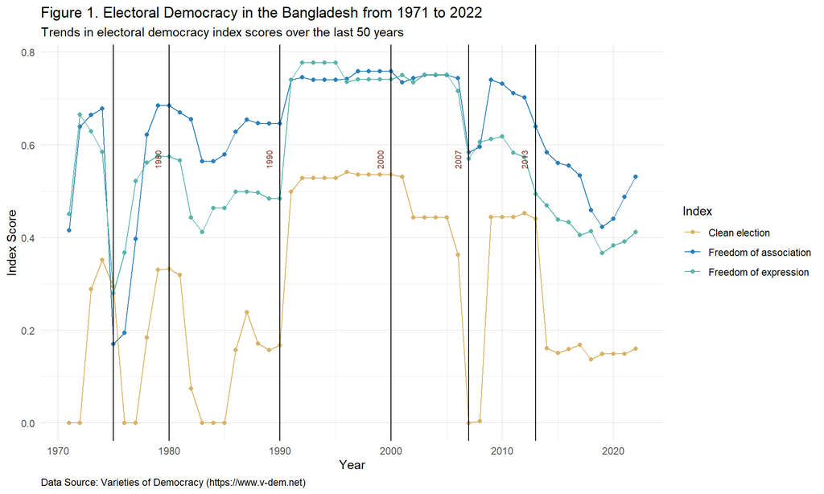

```r
vdemdata_long %>%
  filter(country_name == 'Bangladesh') %>%
  ggplot(aes(x = year, y = score, color = criteria)) +
  geom_point() +
  geom_line() +
  geom_vline(xintercept = c(1975,1980,1990,2000,2007,2013)) +
  annotate("text", x=c(1974,1979,1989,1999,2006,2012), y=0.1,label=c("Before 1975","1980","1990","2000","2007","2013"),
           color="tomato4",size=2.5, angle=90, hjust = -11) +
  labs(title = 'Figure 1. Electoral Democracy in the Bangladesh from 1971 to 2022',
       subtitle = 'Trends in electoral democracy index scores over the last 50 years',
       x = 'Year',
       y = 'Index Score',
       color = 'Index',
       caption = 'Data Source: Varieties of Democracy (https://www.v-dem.net)') +
  scale_color_manual(values = c("#d8b365", "#2c7fb8", "#5ab4ac"),
                    labels = c('Clean election', 'Freedom of association', 'Freedom of expression')) +
  theme_minimal() +
  theme(plot.caption = element_text(hjust = 0))
```

### Pakistan

*Figure 2* illustrates the evolution of electoral democracy in Pakistan from the 1970 to 2022; highlighting the ups and downs within the political climate of the country in the last fifty years.

In the **1970s-90**, Prime Minister Zulfikar Ali Bhutto’s rule ended with a military coup in **1977**, leading to General Zia-ul-Haq’s authoritarian regime. This led to significant drop in both freedom of expression, and freedom of association Moreover, due to dictatorship, clean elections also remained at an all-time low during that period.

Although no longer under military rule, the **1990s** in Pakistan were characterized by unstable democracies, with frequent changes in leadership between Benazir Bhutto’s PPP and Nawaz Sharif’s PML-N, but the democratic governance proved to be fruitful in achieving stability with some indicators of electoral democracy.

In the **2000s,** Pakistan once again saw General Pervez Musharraf’s military rule, leading to a dip in freedom of association. Followed by country-wide protests, and his resignation in 2008, the 2010s led to a civilian rule under democratic governance. This transition led to improving and creating some stability in both freedom of association, and freedom of expression. However, clean election remains a challenge due to a continued struggle with political corruption, economic issues, and the military’s persistent influence in politics.

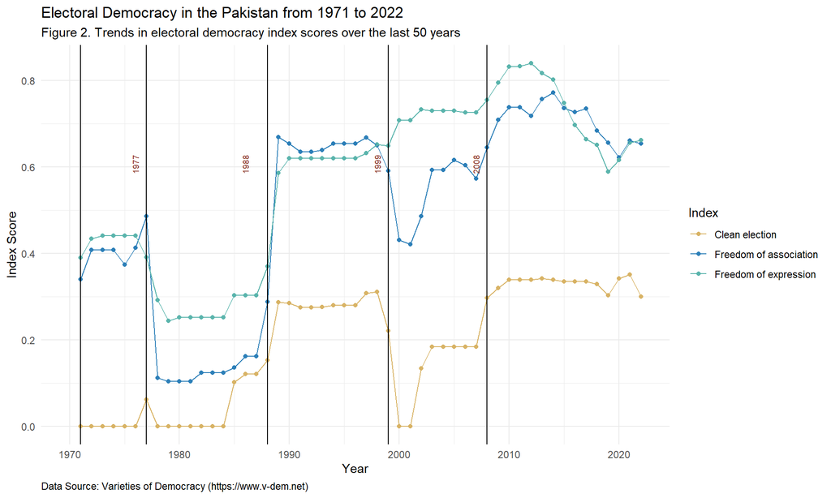

```r
vdemdata_long %>%
  filter(country_name == 'Pakistan') %>%
  ggplot(aes(x = year, y = score, color = criteria)) +
  geom_point() +
  geom_line() + geom_vline(xintercept = c(1971,1977,1988,1999,2008)) +
  annotate("text", x=c(1970,1976,1986,1998,2007), y=0.1,label=c("Before 1971","1977","1988","1999","2008"),
           color="tomato4",size=2.5, angle=90, hjust = -11) +
  labs(title = 'Electoral Democracy in the Pakistan from 1971 to 2022',
       subtitle = 'Figure 2. Trends in electoral democracy index scores over the last 50 years',
       x = 'Year',
       y = 'Index Score',
       color = 'Index',
       caption = 'Data Source: Varieties of Democracy (https://www.v-dem.net)') +
  scale_color_manual(values = c("#d8b365", "#2c7fb8", "#5ab4ac"),
                    labels = c('Clean election', 'Freedom of association', 'Freedom of expression')) +
  theme_minimal() +
  theme(plot.caption = element_text(hjust = 0))
```

### Philippines

In the Philippines, the **1970s** to the **1980s** were considered turbulent times for Philippine democracy as it fell under the dictatorship of President Ferdinand Marcos, Sr. Democracy in the Philippines was officially restored only in **1986** through snap elections, which led to the election of the first female president, Cory Aquino. Her ascent to the presidency was facilitated by large-scale protest demonstrations known as the People Power Revolution, toppling the Marcos regime’s hold on the Philippine government.

Electoral democracy remained stable until **2004**, when then-President Gloria Macapagal Arroyo became embroiled in a widespread presidential election cheating scandal. This explains the sharp decline in clean elections during that period. Nevertheless, other indicators of electoral democracy, such as freedom of association and freedom of expression, remained stable.

It was only in **2016**, with the election of President Rodrigo Duterte, that other indicators of electoral democracy experienced a decline. Duterte, known for his iron-fisted leadership, verbally attacked his critics and encouraged his supporters to do the same. He weaponized the law to jail journalists critical of his administration and his drug war, equating anti-administration beliefs to anti-state and communist ideals. We present this timeline in *Figure 3*.

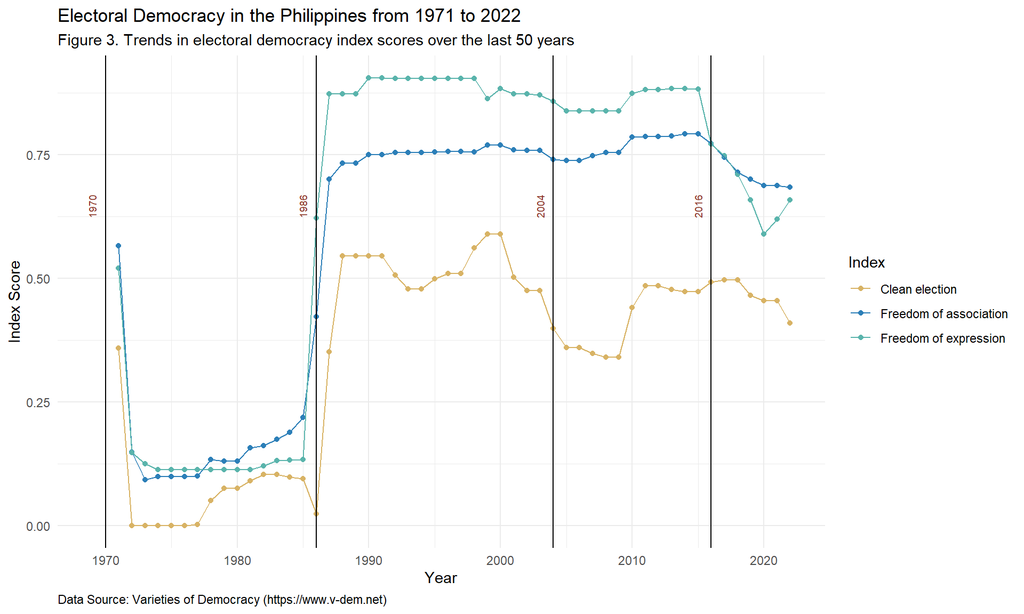

```r
vdemdata_long %>%
  filter(country_name == 'Philippines') %>%
  ggplot(aes(x = year, y = score, color = criteria)) +
  geom_point() +
  geom_line() +
  geom_vline(xintercept = c(1970,1986,2004,2016)) +
  annotate("text", x=c(1969,1985,2003,2015), y=0.1,label=c("1970","1986","2004","2016"),
           color="tomato4",size=2.5, angle=90, hjust = -11) +
  labs(title = 'Electoral Democracy in the Philippines from 1971 to 2022',
       subtitle = 'Figure 3. Trends in electoral democracy index scores over the last 50 years',
       x = 'Year',
       y = 'Index Score',
       color = 'Index',
       caption = 'Data Source: Varieties of Democracy (https://www.v-dem.net)') +
  scale_color_manual(values = c("#d8b365", "#2c7fb8", "#5ab4ac"),
                    labels = c('Clean election', 'Freedom of association', 'Freedom of expression')) +
  theme_minimal() +
  theme(plot.caption = element_text(hjust = 0))
```

## Cross-Country Results

### Individual measures of electoral democracy

As shown in *Figure 4* below, we see large differences in the yearly average scores of the indicators of electoral democracy when comparing the emerging or young democracies of Bangladesh, Pakistan, and Philippines to the United States of America. Among the three indicators, young democracies appear to face the biggest challenges in terms of clean elections, while freedom of expression appears to be relative higher than other indicators.

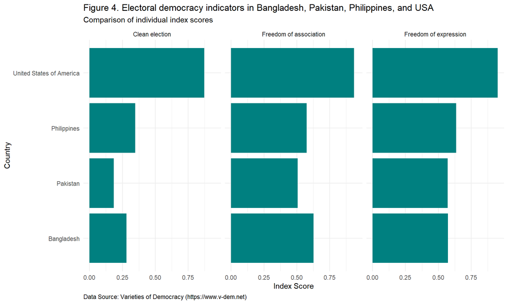

```r
#| Summary of individual measures of electoral democracy

indicators = c('clean_elections' = 'Clean election',
               'freedom_association' = 'Freedom of association',
               'freedom_expression' = 'Freedom of expression')

vdemdata_long %>%
  ggplot(aes(y = country_name, x = score)) +
  geom_bar(stat = "summary", fill = '#008080') +
  facet_wrap(~criteria, labeller = labeller(criteria = indicators)) +
  labs(title = 'Figure 4. Electoral democracy indicators in Bangladesh, Pakistan, Philippines, and USA',
       subtitle = 'Comparison of individual index scores',
       x = 'Index Score',
       y = 'Country',
       caption = 'Data Source: Varieties of Democracy (https://www.v-dem.net)') +
  theme_minimal() +
  theme(plot.title = element_text(hjust = 0),
        plot.caption = element_text(hjust = 0))
```

### Aggregated measure of electoral democracy

```r
# calculate index score
vdemdata_scored <- vdemdata_long %>%
  pivot_wider( # convert the data to a wide format to convert all criteria back as columns
    names_from = "criteria",
    values_from = "score",
  ) %>%
  mutate(electoral_democracy = (0.5 * # calculate based on VDEM formula of electoral democracy index
                                  (elected_index *
                                     clean_elections *
                                     freedom_association *
                                     freedom_expression *
                                     suffrage)) +
           (0.5 * ((.125 * elected_index) +
                     (.25*clean_elections) +
                     (.25 * freedom_association) +
                     (.125 * suffrage) +
                     (.25 * freedom_expression))))
```

```r
vdemdata_scored %>%
  group_by(country_name) %>%
  summarise(yearly_average = mean(electoral_democracy),
            yearly_median = median(electoral_democracy),
            sd = sd(electoral_democracy),
            min = min(electoral_democracy),
            max = min(electoral_democracy)) %>%
  knitr::kable()
```

[output not shown]

The gap in electoral democracy between stable and emerging democracies is also consistent over time, as shown in *Figure 5*. The three emerging democracies, meanwhile, fluctuate in terms of their electoral democracy scores from 1972 to 2022, overtaking each other at different points in time.

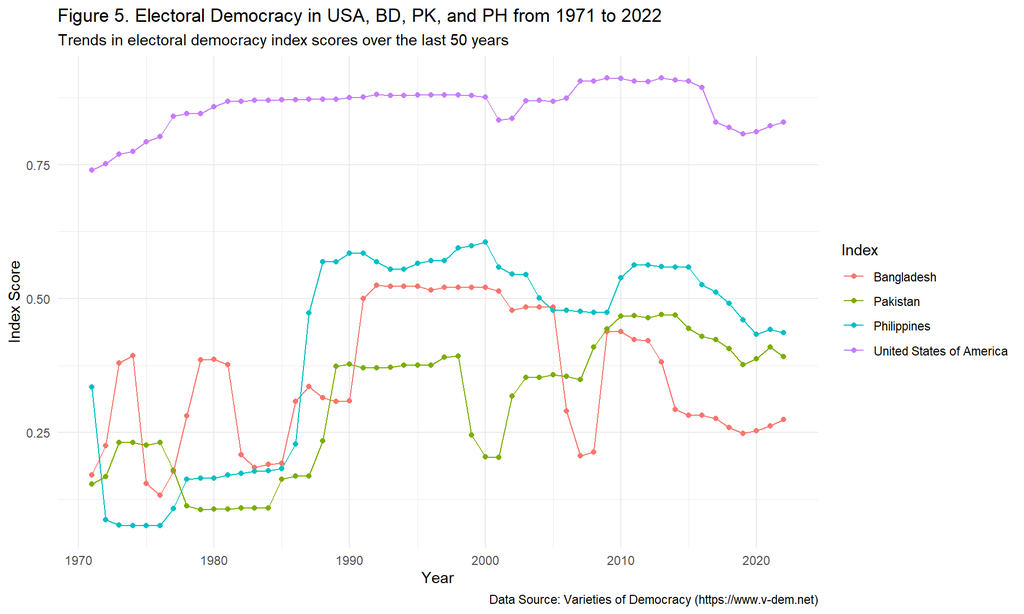

```r
# Aggregate score visualization

vdemdata_scored %>%
  ggplot(aes(x = year, y = electoral_democracy, color = country_name)) +
  geom_point() +
  geom_line() +
  labs(title = 'Figure 5. Electoral Democracy in USA, BD, PK, and PH from 1971 to 2022',
       subtitle = 'Trends in electoral democracy index scores over the last 50 years',
       x = 'Year',
       y = 'Index Score',
       color = 'Index',
       caption = 'Data Source: Varieties of Democracy (https://www.v-dem.net)') +
  theme_minimal()
```

## Comparing three countries’ mean democracy index scores with that of the United States using two-sample t-test

To formally examine the differences between the United States and each of the emerging democracies we used as cases in our research, namely, Bangladesh, Pakistan, and the Philippines, we employed two-sample t-tests comparing mean differences in electoral democracy measures. We summarize the findings of our comparisons below.

### Bangladesh

```r
# Bangladesh x USA t-test

us_vdemdata <- vdemdata_scored %>%
  filter(country_name == 'United States of America')

bd_vdemdata <- vdemdata_scored %>%
  filter(country_name == 'Bangladesh')

ttest_bd <- t.test(us_vdemdata$electoral_democracy,bd_vdemdata$electoral_democracy)
print(ttest_bd)
```

```
    Welch Two Sample t-test

data:  us_vdemdata$electoral_democracy and bd_vdemdata$electoral_democracy
t = 27.839, df = 62.303, p-value < 2.2e-16
alternative hypothesis: true difference in means is not equal to 0
95 percent confidence interval:
 0.4704178 0.5431938
sample estimates:
mean of x mean of y
0.8587533 0.3519475
```

For this two-sample t-test, we consider **null hypothesis, Ho:** there is no difference in the electoral democracy index scores between Bangladesh and the United States. **alternative hypothesis, Ha:** there is a difference between the electoral democracy index scores between these two countries.

While advancing to our t-test, we find an extremely **low p-value** *(<2.2e-16)* which gives us strong evidence to reject the null hypothesis. Therefore, we conclude that there is a statistically significant difference in the mean electoral democracy index scores between Bangladesh and the United States, with Bangladesh *(M = 0.3519475)* being significantly lower than the United States *(M = 0.8587533)*.

### Pakistan

```r
# Pakistan x USA t-test

pk_vdemdata <- vdemdata_scored %>%
  filter(country_name == 'Pakistan')

ttest_pk <- t.test(us_vdemdata$electoral_democracy,pk_vdemdata$electoral_democracy)
print(ttest_pk)
```

```
    Welch Two Sample t-test

data:  us_vdemdata$electoral_democracy and pk_vdemdata$electoral_democracy
t = 31.038, df = 62.841, p-value < 2.2e-16
alternative hypothesis: true difference in means is not equal to 0
95 percent confidence interval:
 0.5174731 0.5886964
sample estimates:
mean of x mean of y
0.8587533 0.3056685
```

For this two-sample t-test, we consider **null hypothesis, Ho:** there is no difference in the electoral democracy index scores between Pakistan and the United States. **alternative hypothesis, Ha:** there is a difference between the electoral democracy index scores between these two countries.

While advancing to our t-test, we find an extremely **low p-value** *(<2.2e-16)* which gives us strong evidence to reject the null hypothesis. Therefore, we conclude that there is a statistically significant difference in the mean electoral democracy index scores between Pakistan and the United States, with Pakistan *(M = 0.3056685)* being significantly lower than the United States *(M = 0.8587533)*.

### Philippines

```r
# Philippines x USA t-test

ph_vdemdata <- vdemdata_scored %>%
  filter(country_name == 'Philippines')

ttest_ph <- t.test(us_vdemdata$electoral_democracy,ph_vdemdata$electoral_democracy)
print(ttest_ph)
```

```
    Welch Two Sample t-test

data:  us_vdemdata$electoral_democracy and ph_vdemdata$electoral_democracy
t = 16.845, df = 56.152, p-value < 2.2e-16
alternative hypothesis: true difference in means is not equal to 0
95 percent confidence interval:
 0.3909252 0.4964454
sample estimates:
mean of x mean of y
0.8587533 0.4150680
```

For this two-sample t-test, we consider **null hypothesis, Ho:** there is no difference in the electoral democracy index scores between Philippines and the United States. **alternative hypothesis, Ha:** there is a difference between the electoral democracy index scores between these two countries.

While advancing to our t-test, we find an extremely **low p-value** *(<2.2e-16)* which gives us strong evidence to reject the null hypothesis. Therefore, we conclude that there is a statistically significant difference in the mean electoral democracy index scores between Philippines and the United States, with Philippines *(M = 0.415068)* being significantly lower than the United States *(M = 0.8587533)*.

## Forecasting democratic trajectories

Finally, we investigated the trajectories of electoral democracies given current trends in democratic backsliding among the three countries we identified. In our study, we employed auto-regregressive integrated moving average (ARIMA) models to forecast succeeding electoral democracy scores. ARIMA models uses values in previous time points as basis for predicting future time points, with the assumption of auto and partial correlation of values between a point and previous points in time-series data. Note that the purpose of these forecasting models is to illustrate diverging or converging democratic trajectories, rather than to provide a definitive prediction of where democracies are headed based on the selected forecasting model. The findings of our projections are illustrated in *Figure 6*.

ARIMA utilizes a parameter called `frequency`, which refers to the seasonality of time periods within a series. Observations within one season are used by the model to predict values. Here, we set seasonality based on number of years within one electoral term since our interest is electoral democracy.

Our projections indicate different trajectories for each of the countries we included in our study. Over the next ten years, our ARIMA model indicates an increase in electoral democracy for Bangladesh and dips for both Pakistan and the Philippines. We also see a slight recovery in the United States in terms of electoral democracy over the next 10 years. These projections, however, must be interpreted with caution, especially with other, non-historical factors that can influence democratic trajectories that were not considered in building these models.

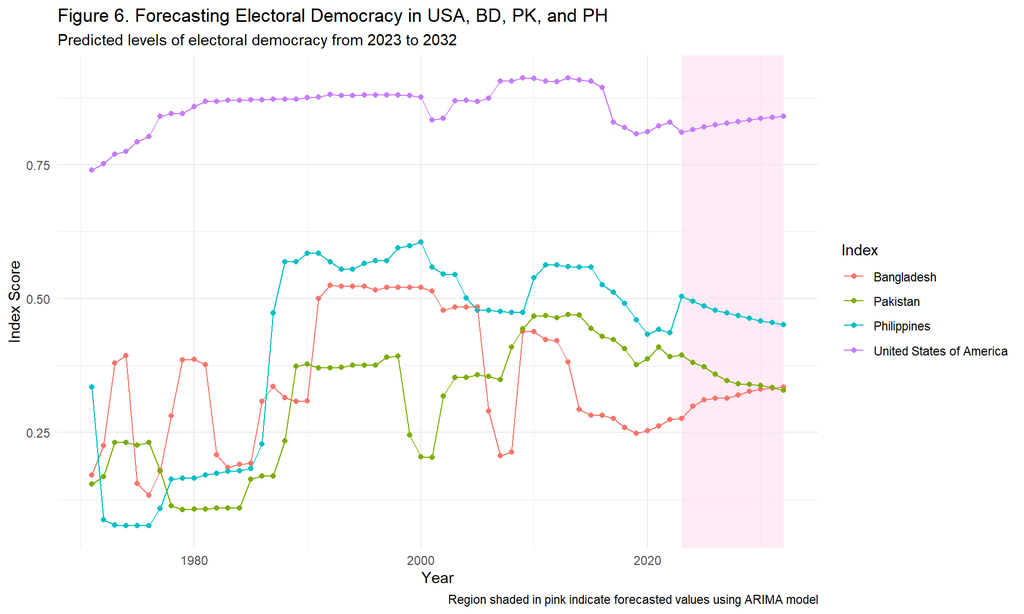

```r
# Developing the forecasting model per country

## USA
ts_america <- vdemdata_scored %>%
  filter(country_name == 'United States of America') %>%
  select(year, electoral_democracy)

ts_democracy_america <- ts(ts_america$electoral_democracy,
                           start = ts_america$year[1], end = ts_america$year[length(ts_america$year)],
                           frequency = 4)


arima_model_usa <- auto.arima(ts_democracy_america, d = ndiffs(ts_democracy_america))
forecast_values_usa <- forecast(arima_model_usa, h = 10)

## Bangladesh

ts_bangladesh <- vdemdata_scored %>%
  filter(country_name == 'Bangladesh') %>%
  select(year, electoral_democracy)

ts_democracy_bangladesh <- ts(ts_bangladesh$electoral_democracy,
                           start = ts_bangladesh$year[1], end = ts_bangladesh$year[length(ts_bangladesh$year)],
                           frequency = 5)

arima_model_bangladesh <- auto.arima(ts_democracy_bangladesh, d = ndiffs(ts_democracy_bangladesh))
forecast_values_bangladesh <- forecast(arima_model_bangladesh, h = 10)


## Pakistan

ts_pakistan <- vdemdata_scored %>%
  filter(country_name == 'Pakistan') %>%
  select(year, electoral_democracy)

ts_democracy_pakistan <- ts(ts_pakistan$electoral_democracy,
                           start = ts_pakistan$year[1], end = ts_pakistan$year[length(ts_pakistan$year)],
                           frequency = 5)

arima_model_pakistan <- auto.arima(ts_democracy_pakistan, d = ndiffs(ts_democracy_pakistan))
forecast_values_pakistan <- forecast(arima_model_pakistan, h = 10)


## Philippines

ts_philippines <- vdemdata_scored %>%
  filter(country_name == 'Philippines') %>%
  select(year, electoral_democracy)

ts_democracy_philippines <- ts(ts_philippines$electoral_democracy,
                           start = ts_philippines$year[1], end = ts_philippines$year[length(ts_philippines$year)],
                           frequency = 6)

arima_model_philippines <- auto.arima(ts_democracy_philippines, d = ndiffs(ts_democracy_philippines))
forecast_values_philippines <- forecast(arima_model_philippines, h = 10)

# Summarizing forecasted Values based on model results

forecast_usa <- forecast_values_usa %>%
  as_tibble() %>%
  select(`Point Forecast`) %>%
  mutate(year = c(2023:2032),
         country_name = 'United States of America') %>%
  rename(electoral_democracy = `Point Forecast`)

forecast_bangladesh <- forecast_values_bangladesh %>%
  as_tibble() %>%
  select(`Point Forecast`) %>%
  mutate(year = c(2023:2032),
         country_name = 'Bangladesh') %>%
  rename(electoral_democracy = `Point Forecast`) %>%
  select(year, country_name, electoral_democracy)

forecast_pakistan <- forecast_values_pakistan %>%
  as_tibble() %>%
  select(`Point Forecast`) %>%
  mutate(year = c(2023:2032),
         country_name = 'Pakistan') %>%
  rename(electoral_democracy = `Point Forecast`) %>%
  select(year, country_name, electoral_democracy)

forecast_philippines <- forecast_values_philippines %>%
  as_tibble() %>%
  select(`Point Forecast`) %>%
  mutate(year = c(2023:2032),
         country_name = 'Philippines') %>%
  rename(electoral_democracy = `Point Forecast`) %>%
  select(year, country_name, electoral_democracy)

# Combining forecast values with dataset for visualization

vdemdata_scored %>%
  select(year, country_name, electoral_democracy) %>%
  rbind(forecast_bangladesh, forecast_pakistan, forecast_philippines, forecast_usa) %>%
  ggplot(aes(x = year, y = electoral_democracy, color = country_name)) +
  geom_rect(aes(xmin = 2023, xmax = 2032, ymin = -Inf, ymax = Inf), fill = 'pink', alpha = 0.01, color = NA) +
  geom_point() +
  geom_line() +
  labs(title = 'Figure 6. Forecasting Electoral Democracy in USA, BD, PK, and PH',
       subtitle = 'Predicted levels of electoral democracy from 2023 to 2032',
       x = 'Year',
       y = 'Index Score',
       color = 'Index',
       caption = 'Region shaded in pink indicate forecasted values using ARIMA model') +
  theme_minimal()
```

# Discussion and Conclusion

Our study focused on the evolution of electoral democracy in developing nations, characterized as young and emerging democracies. Utilizing the VDEM dataset, we specifically examined Bangladesh, Pakistan, and the Philippines, comparing their electoral democracy indicators and aggregated measures with the world’s longest-running democracy, the United States of America.

Through time series analysis, two-sample t-test, and a historical contextualization of significant turning points illustrated in our time series plots, we observed that electoral democracies in these nations faced threats such as military coups (Bangladesh and Pakistan), unstable governments during transitions between forms of governance (e.g., dictatorship to democracy), and the rise of dictators (Bangladesh, the Philippines, and Pakistan). These fluctuations underscore the emergent nature of these democracies, which are still in the early stages of developing democratic systems, fostering democratic political cultures, and reinforcing democratic values. This contrast is particularly evident when comparing democratic indicators to the United States, which appears stable across all democratic indicators. States must consistently monitor aspects of democracy that appear threatened, considering their implications at both the individual and macro levels.

Simultaneously, understanding historical patterns of democratic backsliding can aid younger democracies in preventing attempts by political actors to erode freedoms of association, expression, clean elections, suffrage, and the selection of leaders. Policymakers can enact policies and institutional mechanisms to fortify democratic values.

## References

Barlas, Asma. 2019. *Democracy, Nationalism, and Communalism: The Colonial Legacy in South Asia*. Routledge.

Bermeo, Nancy. 2016. “On Democratic Backsliding.” *J. Democracy* 27: 5.

Bernhard, Michael, Christopher Reenock, and Timothy Nordstrom. 2004. “The Legacy of Western Overseas Colonialism on Democratic Survival.” *International Studies Quarterly* 48 (1): 225–50.

Coppedge, Michael, John Gerring, Carl Henrik Knutsen, Joshua Krusell, Juraj Medzihorsky, Josefine Pernes, Svend-Erik Skaaning, et al. 2019. “The Methodology of ‘Varieties of Democracy’(v-Dem).” *Bulletin of Sociological Methodology/Bulletin de Méthodologie Sociologique* 143 (1): 107–33.

Datta, Ranjan. 2018. “Decolonizing Both Researcher and Research and Its Effectiveness in Indigenous Research.” *Research Ethics* 14 (2): 1–24.

Hoffman, Michael. 2011. “Military Extrication and Temporary Democracy: The Case of Pakistan.” *Democratization* 18 (1): 75–99.

Hutchcroft, Paul D, and Joel Rocamora. 2003. “Strong Demands and Weak Institutions: The Origins and Evolution of the Democratic Deficit in the Philippines.” *Journal of East Asian Studies* 3 (2): 259–92.

Jalal, Ayesha. 2014. *The Struggle for Pakistan: A Muslim Homeland and Global Politics*. Harvard University Press.

Khalid, Talha, and Muhammad Usman Askari. 2023. “Dilemma of Democracy: Reasons for the Failure of Democracy in Pakistan.” *Annals of Human and Social Sciences* 4 (1): 25–33.

Khan, Mohammad Mohabbat, and Md Shahriar Islam. 2014. “Democracy and Good Governance in Bangladesh: Are They Compatible?” *Millennial Asia* 5 (1): 23–40.

Lijphart, Arend. 2013. “Steps in My Research and Thinking about Power Sharing and Democratic Institutions.” *Taiwan Journal of Democracy* 5 (1): 1–7.

Lin, Min-Wei, and Chilik Yu. 2020. “Can Corruption Be Measured? Comparing Global Versus Local Perceptions of Corruption in East and Southeast Asia.” In *Regional Comparisons in Comparative Policy Analysis Studies*, 90–107. Routledge.

Lorch, Jasmin. 2021. “Elite Capture, Civil Society and Democratic Backsliding in Bangladesh, Thailand and the Philippines.” *Democratization* 28 (1): 81–102.

Lührmann, Anna, and Staffan I Lindberg. 2019. “A Third Wave of Autocratization Is Here: What Is New about It?” *Democratization* 26 (7): 1095–1113.

R Core Team. 2022. *R: A Language and Environment for Statistical Computing*. Vienna, Austria: R Foundation for Statistical Computing. https://www.R-project.org/.

Riaz, Ali. 2021. “The Pathway of Democratic Backsliding in Bangladesh.” *Democratization* 28 (1): 179–97.

Ruud, Arild Engelsen. 2018. “Book Review: Ali Riaz. 2016. Bangladesh: A Political History Since Independence.” SAGE Publications Sage India: New Delhi, India.

Smith, Linda Tuhiwai. 2021. *Decolonizing Methodologies: Research and Indigenous Peoples*. Bloomsbury Publishing.

Sultana, Farhana. 2019. “Decolonizing Development Education and the Pursuit of Social Justice.” *Human Geography* 12 (3): 31–46.

Tadem, Teresa S Encarnacion, and Eduardo C Tadem. 2016. “Political Dynasties in the Philippines: Persistent Patterns, Perennial Problems.” *South East Asia Research* 24 (3): 328–40.